# 2019313106 홍현경 1주차 패키지

# 문제3. 각 열마다 unique한 값의 개수 확인

## 3-(1) cus_info 데이터 각 열의 unique 개수 확인

```r
apply(cus_info, 2, n_distinct)
```

```
##         cus_id     sex_dit_cd        cus_age     zip_ctp_cd tco_cus_grd_cd
##          10000              2             12             18              7
```

## 3-(2) act_info 데이터 각 열의 unique 개수 확인

```r
apply(act_info, 2, n_distinct)
```

```
##     act_id     cus_id act_opn_ym
##      23959      10000        418
```

# 문제 4. act_info에서 act_opn_ym의 unique 값 확인 후 이상치가 존재하는 행 삭제

- yyyy-mm의 형태로 표현이 되어야 하는데 0이 존재함

```r
act_info$act_opn_ym %>% unique %>% sort
```

```
##   [1]      0 197603 197611 197805 197909 197912 198210 198409 198501 198510
##  [11] 198604 198606 198610 198612 198701 198702 198703 198706 198707 198708
##  [21] 198709 198710 198711 198712 198801 198802 198803 198804 198805 198806
##  [31] 198807 198808 198809 198810 198811 198812 198901 198902 198903 198904
##  [41] 198905 198906 198907 198908 198909 198910 198911 198912 199001 199002
##  [51] 199003 199004 199005 199006 199007 199008 199009 199010 199011 199012
##  [61] 199101 199102 199103 199104 199105 199106 199107 199108 199109 199110
##  [71] 199111 199112 199201 199202 199203 199204 199205 199206 199207 199208
##  [81] 199209 199210 199211 199212 199301 199302 199303 199304 199305 199306
##  [91] 199307 199308 199309 199310 199311 199312 199401 199402 199403 199404
## [101] 199405 199406 199407 199408 199409 199410 199411 199412 199501 199502
## [111] 199503 199504 199505 199506 199507 199508 199509 199510 199511 199512
## [121] 199601 199602 199603 199604 199605 199606 199607 199608 199609 199610
## [131] 199611 199612 199701 199702 199703 199704 199705 199706 199707 199708
## [141] 199709 199710 199711 199712 199801 199802 199803 199804 199805 199806
```

[output cut: 27 more lines]

- 이는 이상치이므로 act_opn_ym의 값이 0인 친구들의 인덱스를 뽑아서 해당 행을 삭제함

```r
idx <- which(act_info$act_opn_ym == 0)
act_info <- act_info[-idx, ]
```

# 문제 5. act_info에서 act_opn_ym 변수를 년, 월로 분리

```r
act_info$act_opn_ym <- as.character(act_info$act_opn_ym)
act_info <- act_info %>% separate(act_opn_ym, c("act_opn_yy", "act_opn_mm"), 4)
act_info$act_opn_yy <- as.factor(act_info$act_opn_yy)
act_info$act_opn_mm <- as.factor(act_info$act_opn_mm)
```

# 문제 6. cus_info에서 범주형 변수인데 수치형으로 읽힌 경우 mutate_if를 통해 범주형 변수로 변경

- 뒤에서 rename을 이용하여 값을 character형으로 다시 부여해주어야 하기 때문에 character형으로 변환하였음

```r
cus_info <- cus_info %>% mutate_at("cus_age", as.character)
```

# 문제 7. cus_info에서 cus_age 변수를 10세 기준으로 재범주화

- plyr 패키지의 경우 library()를 이용하여 불러오게 되면 dplyr 패키지와 충돌을 일으킴
- 따라서 plyr::function()의 형태로 필요한 함수만 불러옴

```r
cus_info$cus_age <- cus_info$cus_age %>% plyr::revalue(c("0" = "10s", "20" = "20s", "25" = "20s", "30" = "30s", "35" = "30s", "40" = "40s", "45" = "40s", "50" = "50s", "55" = "50s", "60" = "60s", "65" = "60s", "70" = "70s"))
cus_info
```

| cus_id | sex_dit_cd | cus_age | zip_ctp_cd | tco_cus_grd_cd |
| --- | --- | --- | --- | --- |
| 1eec7e43dd6ea34d6be7a9484459e4db1a2da44c5bf311aed5389a2c6ce92b60 | 2 | 20s | 29 | 4 |
| 7e50c268acce884b1a5b78c9b5645b517c4639413c6dc4d7de50799cedab4480 | 2 | 10s | 41 | 9 |
| 36d3cd293c4b02a00103fa1ba33ffbee176173a55df75b1e7ee7d7d24ee55523 | 1 | 70s | 27 | 3 |
| 96b6dea03dc71d9ddb1462e06fdba23def1ddc838debf7cba4484f9f7d9b6631 | 1 | 70s | 41 | 9 |
| 034eb5406bd021a9a88f046e33765efd5b3cd190b395386e93f4ca1340c2d15a | 1 | 70s | 11 | 5 |
| 68512a62994578c8d382fd953f1638bae1d19c269ebed3148930e283eaf76636 | 1 | 70s | 28 | 4 |
| 9a1931d5454b82d8ae9063e7b536468df40eba2923b2ed61d6c807e23be88b8a | 1 | 70s | 11 | 1 |
| 36d3d9105d5a3489e89a3a947c3d623fa80354784dcafa7ebbc7f129d6e78d81 | 1 | 70s | 11 | 2 |
| ff4e513cb490199ce46e7c2f6e10047124b06a86239f3dc0de2af0ab2c7139c3 | 1 | 70s | 26 | 2 |
| a09bd99d65b6d9aab7c25ad16617cd03c9beb1a5a79c67b332edf49ef1c25f83 | 1 | 70s | 43 | 4 |

[output cut: 9990 more lines]

# 문제 8. 데이터 레이블 변경

## 8-(1). 성별 데이터 레이블 변경

- ifelse()를 이용하여 해당 함수 안의 조건문이 참이면 M, 거짓이면 F값을 부여함

```r
cus_info$sex_dit_cd <- ifelse(cus_info$sex_dit_cd == 1, "M", "F")
```

## 8-(2). 주소 데이터 레이블 변경

```r
cus_info$zip_ctp_cd <- as.character(cus_info$zip_ctp_cd) %>%
  plyr::revalue(c("41" = "경기", "11" = "서울", "48" = "경남", "26" = "부산", "27" = "대구", "47" = "경북", "28" = "인천", "44" = "충남", "46" = "전남", "30" = "대전", "29" = "광주", "43" = "충북", "45" = "전북", "42" = "강원", "31" ="울산", "50" = "제주", "36" = "세종"))
```

# 문제 9. cus_id를 제외한 모든 변수들을 factor 형태로 변환

- str()을 이용하여 변환 후 데이터의 구조를 확인해 줌

```r
cus_info <- cus_info %>% mutate(sex_dit_cd = as.factor(sex_dit_cd),
                    cus_age = as.factor(cus_age),
                    zip_ctp_cd = as.factor(zip_ctp_cd),
                    tco_cus_grd_cd = as.factor(tco_cus_grd_cd))
cus_info %>% str
```

```
## 'data.frame':    10000 obs. of  5 variables:
##  $ cus_id        : chr  "1eec7e43dd6ea34d6be7a9484459e4db1a2da44c5bf311aed5389a2c6ce92b60" "7e50c268acce884b1a5b78c9b5645b517c4639413c6dc4d7de50799cedab4480" "36d3cd293c4b02a00103fa1ba33ffbee176173a55df75b1e7ee7d7d24ee55523" "96b6dea03dc71d9ddb1462e06fdba23def1ddc838debf7cba4484f9f7d9b6631" ...
##  $ sex_dit_cd    : Factor w/ 2 levels "F","M": 1 1 2 2 2 2 2 2 2 2 ...
##  $ cus_age       : Factor w/ 7 levels "10s","20s","30s",..: 2 1 7 7 7 7 7 7 7 7 ...
##  $ zip_ctp_cd    : Factor w/ 17 levels "강원","경기",..: 5 2 6 2 9 12 9 9 8 17 ...
##  $ tco_cus_grd_cd: Factor w/ 6 levels "1","2","3","4",..: 4 6 3 6 5 4 1 2 2 4 ...
```

# 문제 10. 문제 4번의 결과를 바탕으로 두 데이터셋 병합 후 data로 저장, 이전 데이터셋은 삭제

```r
data <- full_join(act_info, cus_info, by = "cus_id")
cus_info <- NULL
act_info <- NULL
```

# 문제 11. cus_age를 기준으로 그룹화하여 고객 수, 계좌 수, 1인당 평균 계좌 수 파생변수 생성

- cus_id와 act_id는 모두 고유값이므로 unique %>% length의 형태를 사용하여 수를 count

```r
account_cnt <- data %>%
  group_by(cus_age) %>%
  summarise(cus_cnt = length(unique(cus_id)),
            act_cnt = length(unique(act_id))) %>%
  mutate(mean_acc_cnt = act_cnt / cus_cnt)

account_cnt
```

| cus_age | cus_cnt | act_cnt | mean_acc_cnt |
| --- | --- | --- | --- |
| 10s | 212 | 264 | 1.245283 |
| 20s | 1254 | 2065 | 1.646730 |
| 30s | 2164 | 4158 | 1.921442 |
| 40s | 2798 | 6557 | 2.343460 |
| 50s | 2259 | 6134 | 2.715361 |
| 60s | 959 | 3239 | 3.377477 |
| 70s | 354 | 1540 | 4.350282 |

# Ch2. 시각화

# 문제 1. Bar Graph

## 1-(1). 변수별 결측치의 개수와 비율 시각화

- 변수별 결측치의 개수와 비율에 대한 데이터프레임 생성

```r
na_df <- data %>% lapply(is.na) %>% sapply(sum) %>% sort(decreasing = TRUE) %>% as.data.frame() %>% rename("na_cnt" = ".") %>%
  mutate(na_percentage = paste0(round(na_cnt / nrow(data), 4) * 100, "%"))

na_df <- na_df %>% mutate(var_names = rownames(na_df))

rownames(na_df) <- NULL

na_df
```

| na_cnt | na_percentage | var_names |
| --- | --- | --- |
| 825 | 3.44% | tco_cus_grd_cd |
| 89 | 0.37% | zip_ctp_cd |
| 0 | 0% | act_id |
| 0 | 0% | cus_id |
| 0 | 0% | act_opn_yy |
| 0 | 0% | act_opn_mm |
| 0 | 0% | sex_dit_cd |
| 0 | 0% | cus_age |

- Bar Graph 시각화

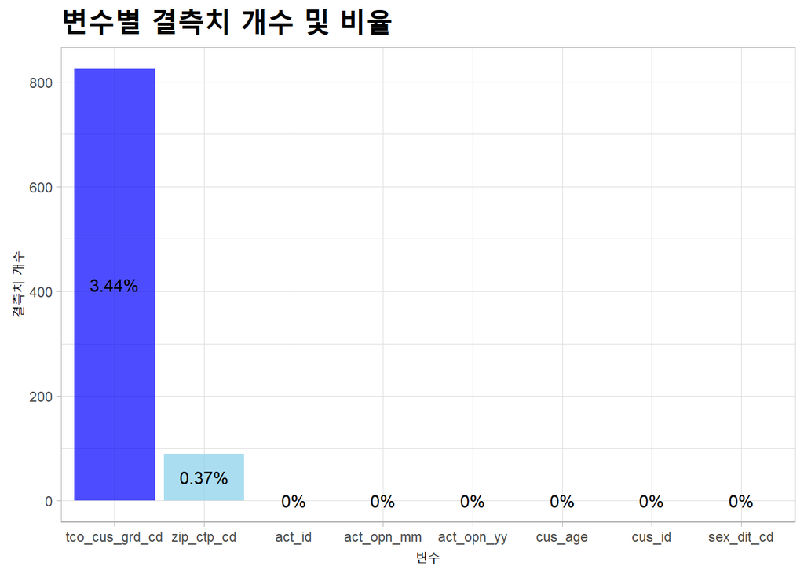

```r
na_df %>% ggplot() +
  geom_bar(aes(x = reorder(var_names, -na_cnt), y = na_cnt, fill = reorder(var_names, -na_cnt)), stat = "identity", alpha = 0.7) +
  geom_text(aes(x = reorder(var_names, -na_cnt), y = na_cnt/2, label = na_percentage))+
  theme_light() +
  scale_fill_manual(values = c("blue", "skyblue", rep("NA", 6))) +
  ggtitle("변수별 결측치 개수 및 비율") +
  xlab("변수") +
  ylab("결측치 개수") +
  theme(
    legend.position = "none",
    plot.title = element_text(size = 20, face = "bold")
  )
```

## 1-(2). 연령대별 2020년 신규 개설 계좌 비율 시각화

- ifelse()를 이용하여 계좌 개설 년도가 2020년인지 구분하는 파생변수 생성

```r
data$act_2020 <- as.factor(ifelse(data$act_opn_yy == "2020", "2020년 개설", "2020년 이전 개설"))
```

- Bar Graph 시각화

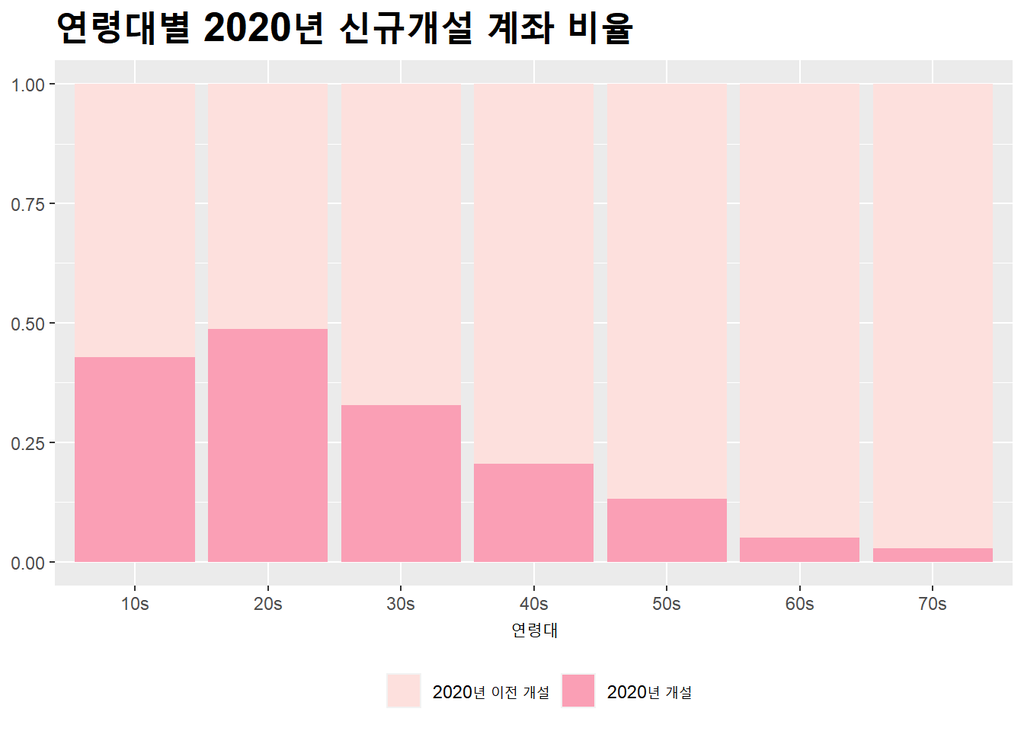

```r
data$act_2020 <- factor(data$act_2020, levels = c("2020년 이전 개설", "2020년 개설"))

left_join(data %>% group_by(cus_age, act_2020) %>% summarise(act_2020_count = n()) %>% group_by(cus_age),
data %>% group_by(cus_age) %>% summarise(age_count = n()), by = "cus_age") %>%
  ggplot(aes(x = cus_age, y = act_2020_count / age_count, group = act_2020, fill = act_2020)) +
  geom_bar(stat = "identity") +
  theme_grey() +
  scale_fill_brewer(palette = "RdPu") +
  ggtitle("연령대별 2020년 신규개설 계좌 비율") +
  xlab("연령대") +
  theme(
    legend.title = element_blank(),
    legend.position = "bottom",
    axis.title.y = element_blank(),
    plot.title = element_text(size = 20, face = "bold")
  )
```

# 문제 2. Line Graph (Time Series Graph)

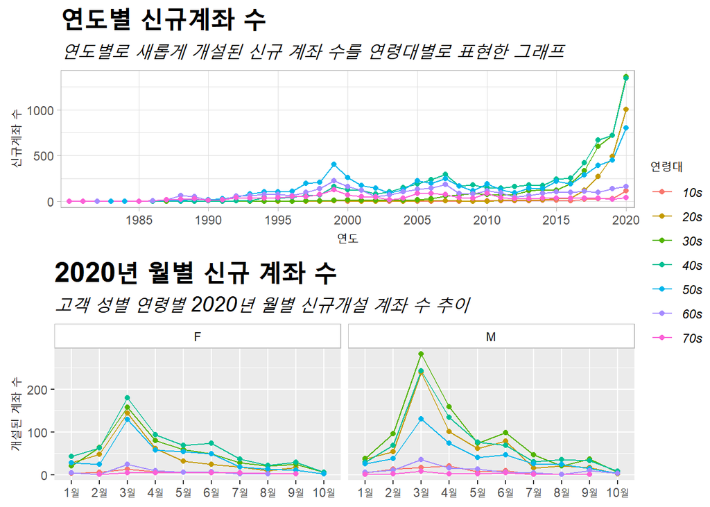

```r
plt1 <- data %>% group_by(act_opn_yy, cus_age) %>% summarise(count = n()) %>%
  ggplot(aes(x = act_opn_yy, y = count, group = cus_age, color = cus_age)) +
  geom_line() +
  geom_point() +
  theme_light() +
  scale_x_discrete(breaks = c(1975, 1980, 1985, 1990, 1995, 2000, 2005, 2010, 2015, 2020)) +
  scale_color_discrete(name = "연령대") +
  ggtitle(label = "연도별 신규계좌 수", subtitle = "연도별로 새롭게 개설된 신규 계좌 수를 연령대별로 표현한 그래프") +
  xlab("연도") +
  ylab("신규계좌 수") +
  theme(
    plot.title = element_text(size = 20, face = "bold"),
    plot.subtitle = element_text(size = 15, face = "italic"),
    legend.text = element_text(face = "italic")
  )
plt2 <- data %>% filter(act_opn_yy == "2020") %>%
  group_by(act_opn_mm, cus_age, sex_dit_cd) %>% summarise(count = n()) %>%
  ggplot(aes(x = act_opn_mm, y = count, group = cus_age, color = cus_age)) +
  geom_line() +
  geom_point() +
  theme_grey() +
  facet_wrap(facets=vars(sex_dit_cd)) +
  ggtitle(label = "2020년 월별 신규 계좌 수", subtitle = "고객 성별 연령별 2020년 월별 신규개설 계좌 수 추이") +
  scale_x_discrete(labels = c("01" = "1월", "02" = "2월", "03" = "3월", "04" = "4월", "05" = "5월", "06" = "6월",
                              "07" = "7월", "08" = "8월", "09" = "9월", "10" = "10월", "11" = "11월", "12" = "12월")) +
  scale_color_discrete(name = "연령대") +
  ylab("개설된 계좌 수") +
  theme(
    strip.background = element_rect(fill = "white", color = "grey"),
    plot.title = element_text(size = 20, face = "bold"),
    plot.subtitle = element_text(size = 15, face = "italic"),
    axis.title.x = element_blank(),
    legend.text = element_text(face = "italic")
  )
ggarrange(plt1, plt2, ncol=1, nrow=2, common.legend = TRUE, legend="right")
```

# 문제 3. Bar Graph + Line Graph

- 300을 곱해주지 않을 경우 y축의 sclae이 맞지 않아 line graph의 형태를 파악하기 어렵다

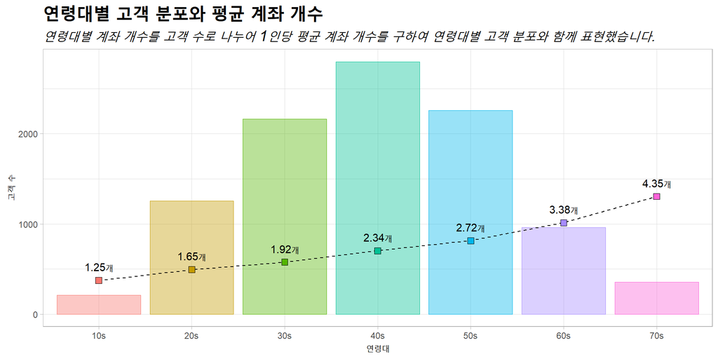

```r
account_cnt %>%
  ggplot() +
  geom_bar(aes(x = cus_age, y = cus_cnt, fill = cus_age, color = cus_age), stat = "identity", alpha = 0.4, cex = 0.3) +
  geom_line(aes(x = cus_age, y = mean_acc_cnt * 300), group = 1, linetype = "dashed") +
  geom_point(aes(x = cus_age, y = mean_acc_cnt * 300, fill = cus_age), shape = 22, size = 3) +
  geom_text(aes(x = cus_age, y = mean_acc_cnt * 300 + 150,
                label = paste(as.character(round(mean_acc_cnt, 2)), "개") %>% str_remove(" "))) +
  theme_light() +
  ggtitle(label = "연령대별 고객 분포와 평균 계좌 개수",
          subtitle = "연령대별 계좌 개수를 고객 수로 나누어 1인당 평균 계좌 개수를 구하여 연령대별 고객 분포와 함께 표현했습니다.") +
  xlab("연령대") +
  ylab("고객 수") +
  theme(
    plot.title = element_text(size = 20, face = "bold"),
    plot.subtitle = element_text(size = 15, face = "italic"),
    legend.position = "none"
  )
```

# 문제 4. Scatter Plot & Box Plot

- 환경에 저장된 데이터를 모두 삭제하고 carData 패키지의 Salaries 데이터셋 불러오기

```r
rm(list=ls()) # 환경에 저장된 데이터 모두 삭제
data(Salaries, package="carData") # Salaries 데이터셋 불러오기
```

- 불러온 데이터 확인

```r
Salaries
```

| rank | discipline | yrs.since.phd | yrs.service | sex | salary |
| --- | --- | --- | --- | --- | --- |
| Prof | B | 19 | 18 | Male | 139750 |
| Prof | B | 20 | 16 | Male | 173200 |
| AsstProf | B | 4 | 3 | Male | 79750 |
| Prof | B | 45 | 39 | Male | 115000 |
| Prof | B | 40 | 41 | Male | 141500 |
| AssocProf | B | 6 | 6 | Male | 97000 |
| Prof | B | 30 | 23 | Male | 175000 |
| Prof | B | 45 | 45 | Male | 147765 |
| Prof | B | 21 | 20 | Male | 119250 |
| Prof | B | 18 | 18 | Female | 129000 |

[output cut: 387 more lines]

## 4-(1). Salaries 데이터셋으로 scatter plot 시각화

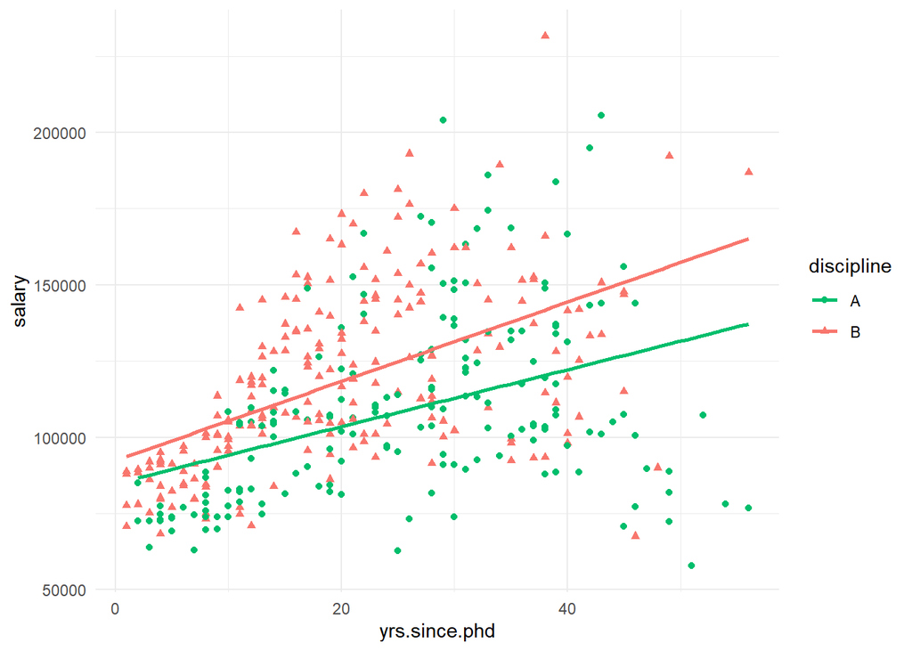

```r
Salaries %>% ggplot(aes(x = yrs.since.phd, y = salary, group = discipline, color = discipline, shape = discipline)) +
  geom_point() +
  geom_smooth(method = "lm", se = FALSE) +
  scale_color_manual(values = c("#00BE6C", "#F8766D")) +
  theme_minimal()
```

## 4-(2). Salaries 데이터셋으로 box plot 시각화

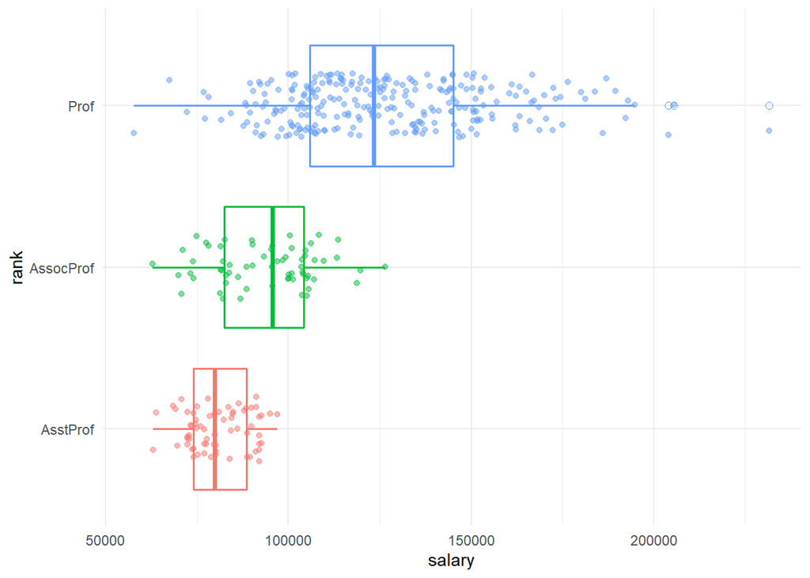

```r
Salaries %>% ggplot(aes(x = rank, y = salary, color = rank)) +
  geom_boxplot(outlier.shape = 1, outlier.size = 2, cex = 0.7) +
  geom_jitter(alpha = 0.5, width = 0.2) +
  coord_flip() +
  theme_minimal() +
  theme(
    legend.position = "none"
  )
```

# Chapter3. 회귀분석

# 문제 1. Salaries 데이터의 수치형 변수만을 이용하여 상관계수 플랏을 그리고 간단히 해석

- symmetric이므로 upper triangular 부분 또는 lower triangular 부분만 보면 ~
- yrs.since.phd와 yrs.service 변수 사이에는 강한 양의 상관관계가 존재함
- 각 변수 사이에 음의 상관관계는 존재하지 않으며, 모두 양의 상관관계를 보임
- 그러나 yrs.since.phd와 yrs.service에 비하면 모두 약한 양의 상관관계를 보임

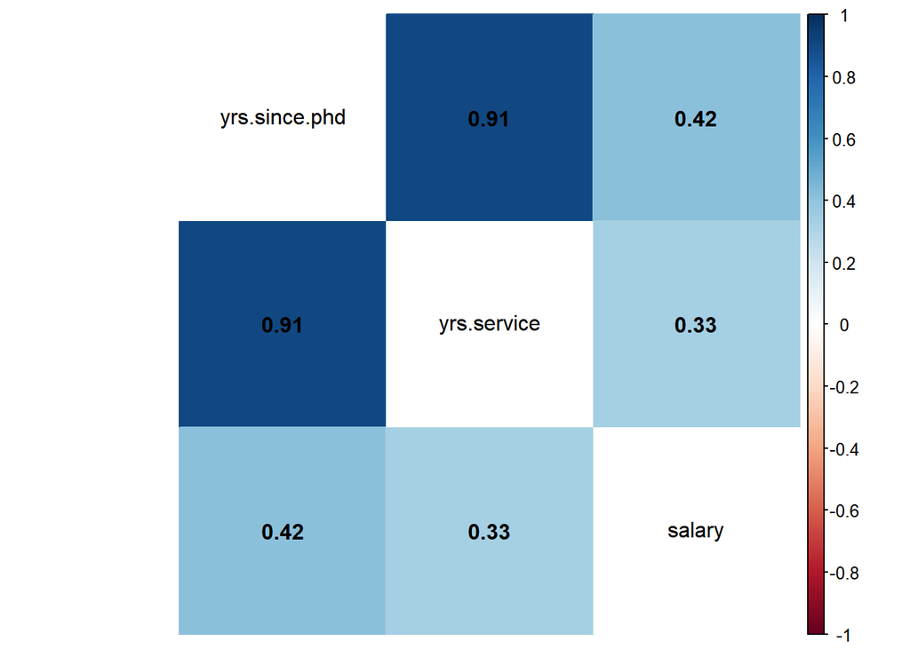

```r
idx <- Salaries %>% sapply(is.numeric) # 수치형 변수의 column index
cor(Salaries[,idx]) %>% corrplot(method = "color", diag = FALSE, addCoef.col = "black", tl.pos = "d", tl.col = "black")
```

# 문제 2. two sample t-test (two-sided)

- H0: 성별에 따른 salary의 평균은 다르지 않다.
- H1: 성별에 따른 salary의 평균에는 차이가 존재한다.
- alpha = 0.05에서 p-value값이 0.00266으로 0.05보다 작기 떄문에 귀무가설을 기각한다.
- 따라서, 성별에 따라 salary의 평균에 유의미한 차이가 존재한다.

```r
male <- Salaries %>% filter(sex == "Male")
female <- Salaries %>% filter(sex == "Female")

# t-test 시행
t.test(male$salary, female$salary, paired = FALSE, alternative = "two.sided")
```

```
##
##  Welch Two Sample t-test
##
## data:  male$salary and female$salary
## t = 3.1615, df = 50.122, p-value = 0.002664
## alternative hypothesis: true difference in means is not equal to 0
## 95 percent confidence interval:
##   5138.102 23037.916
## sample estimates:
## mean of x mean of y
##  115090.4  101002.4
```

# 문제 3. 데이터를 7:3 비울로 train/test 분리

```r
set.seed(2728)
train_idx <- createDataPartition(Salaries$salary, p = 0.7, list = FALSE)
train <- Salaries[train_idx, ]
test <- Salaries[-train_idx, ]
```

# 문제 4. train 데이터를 이용하여 salary를 종속변수, 나머지 변수들을 독입변수로 하는 회귀 모형을 만든 후 결과 간단히 해석

- F-test의 p-value < 2.2e-16이므로 모든 회귀계수가 0이라는 귀무가설을 기각한다.
- t-test의 p-value를 통해 rankAssocProf, rankProf, disciplineB변수의 경우 타 변수들이 모두 적합되어 있을 때 해당 변수를 추가적으로 적합시키면 회귀식의 설명력이 통계적으로 유의미하게 증가함을 확인할 수 있다.
- t-test의 p-value 값이 높아 통계적으로 유의하지 않다고 나온 변수들은 실제로 y값과 관계가 없는지는 알 수 없다. 위의 상관관계 플랏에서 알 수 있듯이 변수간 다중공산성 문제가 발생하기 때문이다.
- Multiple R-squared의 값은 0.4553, 변수의 개수에 대한 보정이 이루어진 Adjusted R-squared의 값은 0.4433으로 회귀식의 설명력이 높지는 않은 것을 알 수 있다.
- discipline, rank, sex변수가 범주형 독립변수에 해당한다.
- 범주형 독립변수가 가지는 회귀계수의 경우 해당 변수의 baseline category와의 값 차이로 해석 가능하다.

```r
lm_fit <- lm(salary ~., data = train)
summary(lm_fit)
```

```
##
## Call:
## lm(formula = salary ~ ., data = train)
##
## Residuals:
##    Min     1Q Median     3Q    Max
## -63182 -13143  -1847  11327  87832
##
## Coefficients:
##               Estimate Std. Error t value Pr(>|t|)
## (Intercept)    69053.1     5237.9  13.183  < 2e-16 ***
## rankAssocProf  15116.9     4825.9   3.132  0.00192 **
## rankProf       45506.8     4904.2   9.279  < 2e-16 ***
## disciplineB    12783.4     2676.0   4.777 2.91e-06 ***
## yrs.since.phd    279.3      283.8   0.984  0.32592
## yrs.service     -274.3      242.7  -1.130  0.25932
## sexMale         2892.8     4629.9   0.625  0.53261
## ---
## Signif. codes:  0 '***' 0.001 '**' 0.01 '*' 0.05 '.' 0.1 ' ' 1
##
## Residual standard error: 21630 on 273 degrees of freedom
## Multiple R-squared:  0.4553, Adjusted R-squared:  0.4433
## F-statistic: 38.03 on 6 and 273 DF,  p-value: < 2.2e-16
```

- 회귀모형의 성능을 평가할 수 있는 지표로는 RMSE, MSE, MAE, R squared 등이 있다.
- MSE는 실제 값과 회귀식을 통해 예측한 값의 차를 제곱하여 평균낸 것이다. 여기에서 S는 Squared!
- RMSE는 MSE에 루트를 씌운 것이다! 여기에서 R은 Root!
- MAE는 실제 값과 회귀식을 통해 예측한 값의 차에 절댓값을 씌운 후 평균낸 것이다. 여기에서 A는 Absolute!
- R squared는 총 변동에서 회귀식이 설명하는 부분을 나타낸다. 회귀식의 설명력을 나타내게 되는데, 여기에서 변수의 개수가 증가하게 되면 회귀식의 설명력은 증가할 수 밖에 없다. 따라서, Adjusted R squared 값을 이용하면 변수의 개수가 다른 두 회귀식의 설명력을 비교할 수 있다! (Adjusted )R squared 값이 1에 가까울수록 좋은 회귀식이라고 할 수 있겠다!

```r
train_RMSE <- mean((train$salary - lm_fit$fitted.values)^2) %>% sqrt
train_RMSE
```

```
## [1] 21358.84
```

```r
pred <- lm_fit %>% predict(test)

data.frame(RMSE = RMSE(pred, test$salary),
           R2 = R2(pred, test$salary),
          MAE = MAE(pred, test$salary))
```

| RMSE | R2 | MAE |
| --- | --- | --- |
| 24785.88 | 0.456991 | 17089.12 |

- training RMSE보다 test RMSE가 더 높은 것을 확인할 수 있다.
- 변수 선택을 통해 다중공산성 문제를 해결한 후 다시 모델링을 해서 성능을 높여보는 것도 시도해보면 좋을 것 같다!